# In-Class T-Tests

Johanna Ravenhurst

2022-11-20

#I had to miss this class and I did not work with other students to complete this assignment.

```r
require(palmerpenguins)
```

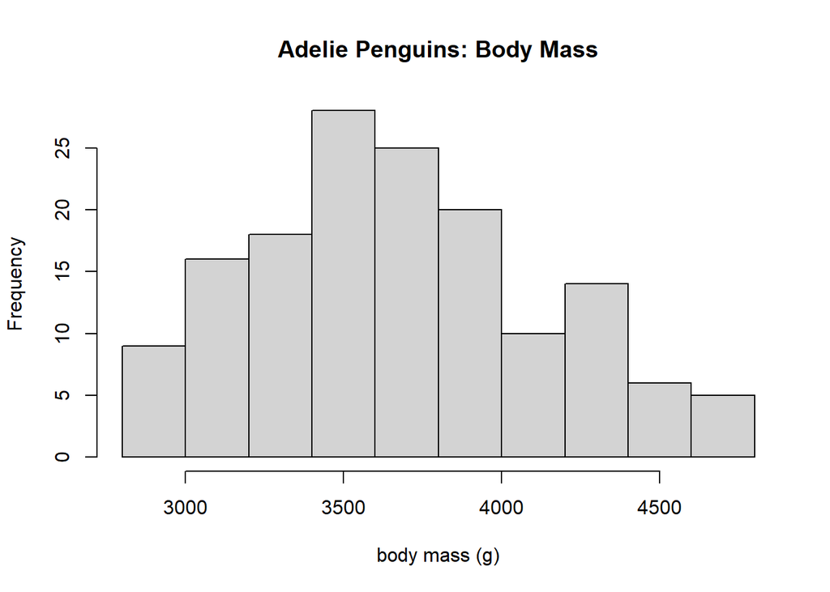

```r
dat_ade = droplevels(subset(penguins, species == "Adelie"))
hist(dat_ade$body_mass_g, main = "Adelie Penguins: Body Mass", xlab = "body mass (g)")
```

#Q1 (2 pts.): Create separate boxplots of body mass for male and female Adelie penguins. Your boxplots do not have to be in the same panel like mine. Show the R-code you used to make the plots.

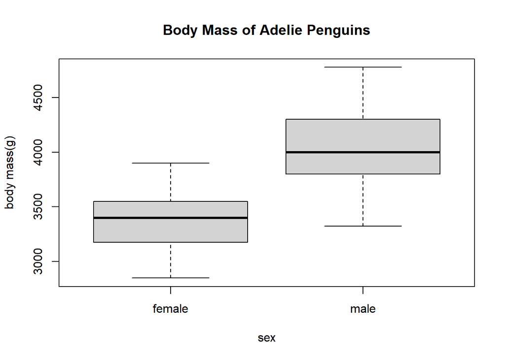

```r
#head(dat_ade)
 boxplot(
    body_mass_g ~ sex, data = dat_ade,
    main = "Body Mass of Adelie Penguins",
    ylab = "body mass(g)",
    xlab = "sex")
```

##One-sample t-test

#Q2 (1 pt.): Perform a one-sample t-test of the alternative hypothesis that female Adelie penguins have a body mass different from zero grams. Note that this is a very silly alternative hypothesis. Is this a one- or two-tailed test? Show your R-code.

```r
dat_ade_f = droplevels(subset(dat_ade, sex == "female"))
t.test(body_mass_g ~ 1, data = dat_ade_f, alternative = c("two.sided"), mu = 0)
```

```
##
##  One Sample t-test
##
## data:  body_mass_g
## t = 106.85, df = 72, p-value < 2.2e-16
## alternative hypothesis: true mean is not equal to 0
## 95 percent confidence interval:
##  3305.985 3431.687
## sample estimates:
## mean of x
##  3368.836
```

```r
#This is a two-tailed test because the alternative hypothesis is non-directional. The alternative hypothesis is that the female Adelie penguins have a body mass either higher or lower than 0 grams.
```

#Q3 (1 pt.): Describe your conclusions based on the p-value of the t-test. #The p-value is <0.0001 so I conclude that we have significant evidence to reject the null hypothesis that the mean body mass of female Adelie penguins is equal to zero. Our data provides evidence that the mean body mass is different from 0 (either higher or lower).

#Q4 (1 pt.): Now, conduct a slightly less silly test: perform a one-sample t-test of the alternative hypothesis that male Adelie penguins have a mean body mass greater than 4000 grams. Is this a one- or two-tailed test?

```r
dat_ade_m = droplevels(subset(dat_ade, sex == "male"))
t.test(body_mass_g ~ 1, data = dat_ade_m, alternative = c("greater"), mu = 4000)
```

```
##
##  One Sample t-test
##
## data:  body_mass_g
## t = 1.0715, df = 72, p-value = 0.1438
## alternative hypothesis: true mean is greater than 4000
## 95 percent confidence interval:
##  3975.856      Inf
## sample estimates:
## mean of x
##  4043.493
```

```r
#This is a one-tailed test because the alternative hypothesis specifies a direction.
```

#Q5 (1 pt.): Describe your conclusions based on the p-value of the t-test.

#The p-value is higher than 0.05, so I do not reject the null hypothesis the the true mean body mass of male Adelie penguins is less than or equal to 4000 g. We do not have sufficient evidence from our data to reject the null hpyothesis.

##Two-sample t-test

#Q6 (2 pts.): Conduct a two-sample t-test of the alternative hypothesis that male and female Adelie penguins have different mean body masses. Show your R code.

```r
t.test(body_mass_g ~ sex, data = dat_ade, alternative = c("two.sided"))
```

```
##
##  Welch Two Sample t-test
##
## data:  body_mass_g by sex
## t = -13.126, df = 135.69, p-value < 2.2e-16
## alternative hypothesis: true difference in means between group female and group male is not equal to 0
## 95 percent confidence interval:
##  -776.3012 -573.0139
## sample estimates:
## mean in group female   mean in group male
##             3368.836             4043.493
```

#Q7 (1 pt.): Describe your conclusions based on the p-value of the t-test.

#The p-value is <0.001, so I conclude that we have evidence to reject the null hypothesis that the mean body mass of male and female penguins is the same (or that the difference between the means is 0).

#Q8 (2 pts.): Conduct a two-sample (one-tailed) t-test of the directional alternative hypothesis that male Adelie penguins are heavier than females. Show your R code.

```r
t.test(dat_ade_m$body_mass_g, dat_ade_f$body_mass_g, alternative = c("greater"))
```

```
##
##  Welch Two Sample t-test
##
## data:  dat_ade_m$body_mass_g and dat_ade_f$body_mass_g
## t = 13.126, df = 135.69, p-value < 2.2e-16
## alternative hypothesis: true difference in means is greater than 0
## 95 percent confidence interval:
##  589.5351      Inf
## sample estimates:
## mean of x mean of y
##  4043.493  3368.836
```

```r
#Is this the correct way to specify the alternative hypothesis that males are heavier than females? I listed males first, but I'm not sure if there is a better way to give R information about the specific group we think has the mean with a higher value.
```

#Q9 (2 pts.): Conduct a two-sample (one-tailed) t-test of the directional alternative hypothesis that male Adelie penguins are lighter than females. Show your R code.

```r
t.test(dat_ade_m$body_mass_g, dat_ade_f$body_mass_g, alternative = c("less"))
```

```
##
##  Welch Two Sample t-test
##
## data:  dat_ade_m$body_mass_g and dat_ade_f$body_mass_g
## t = 13.126, df = 135.69, p-value = 1
## alternative hypothesis: true difference in means is less than 0
## 95 percent confidence interval:
##    -Inf 759.78
## sample estimates:
## mean of x mean of y
##  4043.493  3368.836
```

#Q10 (2 pts.): Speculate on why the p-values are so drastically different in the two directions. #The first test’s null hypothesis was that the female and male penguins have the same mean body mass. The alternative hypothesis was that the male penguins have a higher mean body mass than females. The p-value is <0.001, indicating that we should reject the null hypothesis that the difference in means is 0. We have evidence to support the alternative hypothesis that male Adelie penguins are heavier than female Adelie penguins on avarage. #The second test’s null hypothesis was that the female and male penguins have the same mean body mass. The alternative hypothesis was that the male penguins have a lower mean body mass than females. The p-value is 1, indicating that we should NOT reject the null hypothesis that the difference in means is 0.

#Looking at the sample estimates, the male penguins have a much higher mean body mass than female penguins. I think the p-values are so drastically different because the male penguin mean body mass is so much higher than females.

```r
#Extra - trying out the Shapiro test and Bartlett test for these data

shapiro.test(dat_ade$body_mass_g)
```

```
##
##  Shapiro-Wilk normality test
##
## data:  dat_ade$body_mass_g
## W = 0.98071, p-value = 0.0324
```

```r
#This p-value is actually quite low, so this could lead us to reject the null hypothesis that the data are normally distributed.

bartlett.test(body_mass_g ~ sex, data = dat_ade)
```

```
##
##  Bartlett test of homogeneity of variances
##
## data:  body_mass_g by sex
## Bartlett's K-squared = 4.5168, df = 1, p-value = 0.03356
```

```r
#The p-value is low again, so it indicates that the assumption of equal variance might not be met.
```